# 1. Contexto

# 2. Importando librerias/modulos

Para poder realizar el objetivo de esta practica, se es necesario las librerias de **Pandas**,**MatlPlotLib** y **Seaborn**

```python
# Importando liberias
import pandas as pd
import matplotlib.pyplot as plt
import seaborn as sns
#import numpy as np
```

# 3. Lectura del dataset

```python
# Lectura del dataset
ruta = "../results/dataset_penguins_clean.csv"
data = pd.read_csv(ruta)
print(data)

data.columns #ver las comlumnas del CSV
data.describe() #ver variables numericas
data.isna() #ver datos fatantes
data.isna().sum() #contar la cantidade datos faltantes#
```

```
     rowid    species     island  bill_length_mm  bill_depth_mm  \
0        1     Adelie  Torgersen            39.1           18.7
1        2     Adelie  Torgersen            39.5           17.4
2        3     Adelie  Torgersen            40.3           18.0
3        5     Adelie  Torgersen            36.7           19.3
4        6     Adelie  Torgersen            39.3           20.6
..     ...        ...        ...             ...            ...
328    340  Chinstrap      Dream            55.8           19.8
329    341  Chinstrap      Dream            43.5           18.1
330    342  Chinstrap      Dream            49.6           18.2
331    343  Chinstrap      Dream            50.8           19.0
332    344  Chinstrap      Dream            50.2           18.7

     flipper_length_mm  body_mass_g     sex  year  edad_actual
0                181.0       3750.0    male  2007           16
1                186.0       3800.0  female  2007           16
2                195.0       3250.0  female  2007           16
3                193.0       3450.0  female  2007           16
4                190.0       3650.0    male  2007           16
..                 ...          ...     ...   ...          ...
328              207.0       4000.0    male  2009           14
329              202.0       3400.0  female  2009           14
330              193.0       3775.0    male  2009           14
331              210.0       4100.0    male  2009           14
332              198.0       3775.0  female  2009           14

[333 rows x 10 columns]
```

```
rowid                0
species              0
island               0
bill_length_mm       0
bill_depth_mm        0
flipper_length_mm    0
body_mass_g          0
sex                  0
year                 0
edad_actual          0
dtype: int64
```

# 4. Filtro de las columnas numericas

Para poder realizar nuestros graficos de Calor y Dispersion, se es necesario solo tener en cuenta las columnas numericas, para este caso tenermos cinco columnas numericas

```python
#Filtrando comlumnas numericas
filtro = ['bill_length_mm','bill_depth_mm',
          'flipper_length_mm', 'body_mass_g', 'year']
data=data[filtro]

#Mostrando e nuevo DF
data
```

|  | bill_length_mm | bill_depth_mm | flipper_length_mm | body_mass_g | year |
| --- | --- | --- | --- | --- | --- |
| 0 | 39.1 | 18.7 | 181.0 | 3750.0 | 2007 |
| 1 | 39.5 | 17.4 | 186.0 | 3800.0 | 2007 |
| 2 | 40.3 | 18.0 | 195.0 | 3250.0 | 2007 |
| 3 | 36.7 | 19.3 | 193.0 | 3450.0 | 2007 |
| 4 | 39.3 | 20.6 | 190.0 | 3650.0 | 2007 |
| ... | ... | ... | ... | ... | ... |
| 328 | 55.8 | 19.8 | 207.0 | 4000.0 | 2009 |
| 329 | 43.5 | 18.1 | 202.0 | 3400.0 | 2009 |
| 330 | 49.6 | 18.2 | 193.0 | 3775.0 | 2009 |
| 331 | 50.8 | 19.0 | 210.0 | 4100.0 | 2009 |
| 332 | 50.2 | 18.7 | 198.0 | 3775.0 | 2009 |

333 rows × 5 columns

# 5. Graficando

Una matriz de correlación es una herramienta estadística que muestra la intensidad y la dirección de la relación entre dos o más variables. Se utiliza mucho en campos como las finanzas, la economía, la psicología y la biología, porque ayuda a entender cómo se relacionan entre sí distintas cosas.

```python
#Creando la mtriz de correlacion
print("Matriz de Correlacion:\n")
matriz_correlacion=data.corr().round(2)
matriz_correlacion
```

```
Matriz de Correlacion:
```

|  | bill_length_mm | bill_depth_mm | flipper_length_mm | body_mass_g | year |
| --- | --- | --- | --- | --- | --- |
| bill_length_mm | 1.00 | -0.23 | 0.65 | 0.59 | 0.03 |
| bill_depth_mm | -0.23 | 1.00 | -0.58 | -0.47 | -0.05 |
| flipper_length_mm | 0.65 | -0.58 | 1.00 | 0.87 | 0.15 |
| body_mass_g | 0.59 | -0.47 | 0.87 | 1.00 | 0.02 |
| year | 0.03 | -0.05 | 0.15 | 0.02 | 1.00 |

## 5.1 Mapa de Calor en Seaborn con **heatmap** (antes)

La función **heatmap** permite crear mapas de calor o gráficos de correlación en Python con seaborn. Puedes pasar un conjunto de datos 2D o un data frame de pandas. En caso de utilizar un data frame de pandas los nombres de las filas y las columnas serán usados como etiquetas para los ejes.

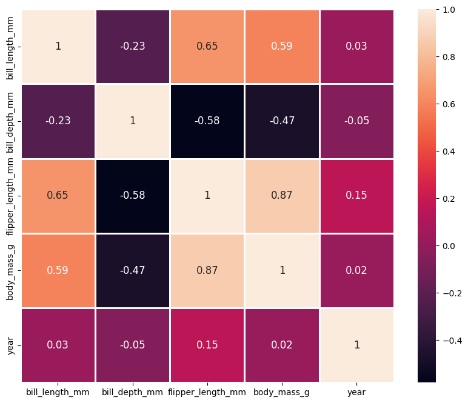

```python
#ruta = "../results/dataset_penguins_clean.csv"
# Diagrama de Calor
plt.figure(figsize=(10, 8))
sns.heatmap(data=matriz_correlacion,  # pasandoles los datos CSV con el nuevo DF
            annot=True,  # Mostrar los datos dentos de los cuadros
            square=True,  # Celdas cuadrdas
            annot_kws={'size': 12},  # Tamaño de los datos en los cuadros
            linecolor='white',  # Color del borde de los cuadros
            linewidths=0.75)  # Grosor del borde de los cuadros
plt.show()
```

```
No artists with labels found to put in legend.  Note that artists whose label start with an underscore are ignored when legend() is called with no argument.
```

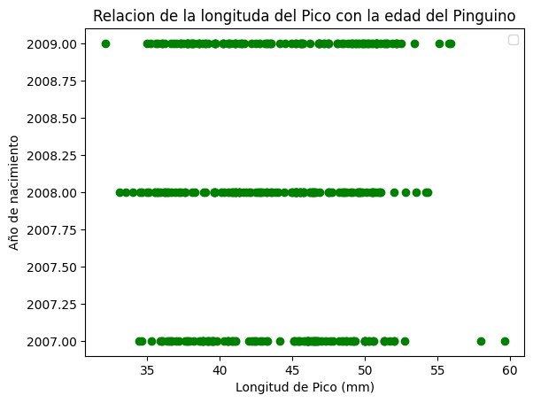

```python
#Datos para el grafico de dispersion
x=data['bill_length_mm']
y=data['year']
plt.scatter(x,y, color="g")
plt.xlabel('Longitud de Pico (mm)')
plt.ylabel('Año de nacimiento')
plt.title("Relacion de la longitud del Pico con la edad del Pinguino")
plt.legend()
plt.show()
```

# 5.2 Mapa de Calor en Seaborn con **heatmap** (despues)

Anteriormente se hizo el mapa de calor sin la fecha calculada real contra la fecha actual, es decir, año en este mapa de calor, se vera la edad real del pinguino a fecha de hoy.

```python
#ruta = "../results/dataset_penguins_clean.csv"
#Filtrando comlumnas numericas
filtro = ['bill_length_mm','bill_depth_mm',
          'flipper_length_mm', 'body_mass_g', 'year','edad_actual']
data=data[filtro]

#Mostrando e nuevo DF
data
```

[output not shown]

```python
#Creando la mtriz de correlacion
print("Matriz de Correlacion:\n")
matriz_correlacion=data.corr().round(2)
matriz_correlacion
```

```
Matriz de Correlacion:
```

|  | bill_length_mm | bill_depth_mm | flipper_length_mm | body_mass_g | year | edad_actual |
| --- | --- | --- | --- | --- | --- | --- |
| bill_length_mm | 1.00 | -0.23 | 0.65 | 0.59 | 0.03 | -0.03 |
| bill_depth_mm | -0.23 | 1.00 | -0.58 | -0.47 | -0.05 | 0.05 |
| flipper_length_mm | 0.65 | -0.58 | 1.00 | 0.87 | 0.15 | -0.15 |
| body_mass_g | 0.59 | -0.47 | 0.87 | 1.00 | 0.02 | -0.02 |
| year | 0.03 | -0.05 | 0.15 | 0.02 | 1.00 | -1.00 |
| edad_actual | -0.03 | 0.05 | -0.15 | -0.02 | -1.00 | 1.00 |

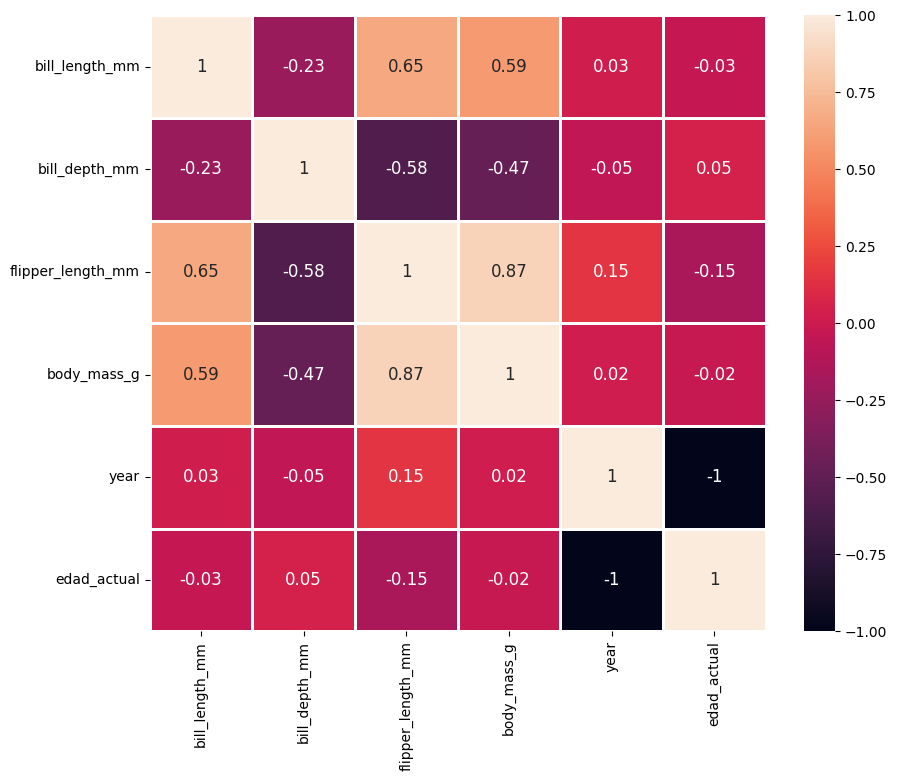

```python
# Diagrama de Calor
plt.figure(figsize=(10, 8))
sns.heatmap(data=matriz_correlacion,  # pasandoles los datos CSV con el nuevo DF
            annot=True,  # Mostrar los datos dentos de los cuadros
            square=True,  # Celdas cuadrdas
            annot_kws={'size': 12},  # Tamaño de los datos en los cuadros
            linecolor='white',  # Color del borde de los cuadros
            linewidths=0.75)  # Grosor del borde de los cuadros
plt.show()
```

```
No artists with labels found to put in legend.  Note that artists whose label start with an underscore are ignored when legend() is called with no argument.
```

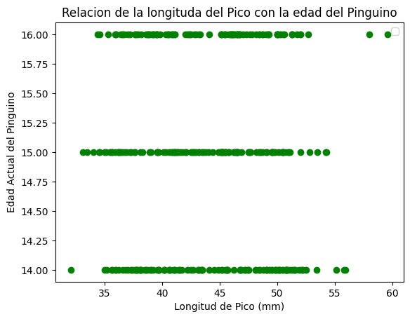

```python
#Datos para el grafico de dispersion
x=data['bill_length_mm']
y=data['edad_actual']
plt.scatter(x,y, color="g")
plt.xlabel('Longitud de Pico (mm)')
plt.ylabel('Edad Actual del Pinguino')
plt.title("Relacion de la longitud del Pico con la edad del Pinguino")
plt.legend()
plt.show()
```